# Question 1.

(25 points)

There are three types of coins which have different probabilities of landing heads when tossed:

– Type A coins are fair, with probability 0.5 of heads

– Type B coins are bent and have probability 0.6 of heads

– Type C coins are bent and have probability 0.9 of heads

Suppose I have a drawer containing 5 coins: 2 of type A, 2 of type B, and 1 of type C. I reach into the drawer and pick a coin at random. Without showing you the coin I flip it once and get heads (i.e. event D). What is the probability it is

- type A (i.e. $P(H = A|D)$)?
- Type B (i.e. $P(H = B|D)$)?
- Type C (i.e. $P(H =C|D)$)?

Fill out table below with your answers.

`Step1:prior knowleges`

The sample space of B is {a,a,b,b,c}, so the probability to pick up an A Type coin $P(H=A)=2/5$, so as $P(H=B)=2/5$, $P(H=C)=0.2$

| hypothesis | prior | likelihood | posterior |
| --- | --- | --- | --- |
| H | P(H) | P(D\|H) | P(H\|D) |
| A | 0.4 |  |  |
| B | 0.4 |  |  |
| C | 0.2 |  |  |

`Step2: fill out the specific probabilities when different coin type is selected`

| hypothesis | prior | likelihood | posterior |
| --- | --- | --- | --- |
| H | P(H) | P(D\|H) | P(H\|D) |
| A | 0.4 | 0.5 |  |
| B | 0.4 | 0.6 |  |
| C | 0.2 | 0.9 |  |

`Step3: get P(D)`

$ $

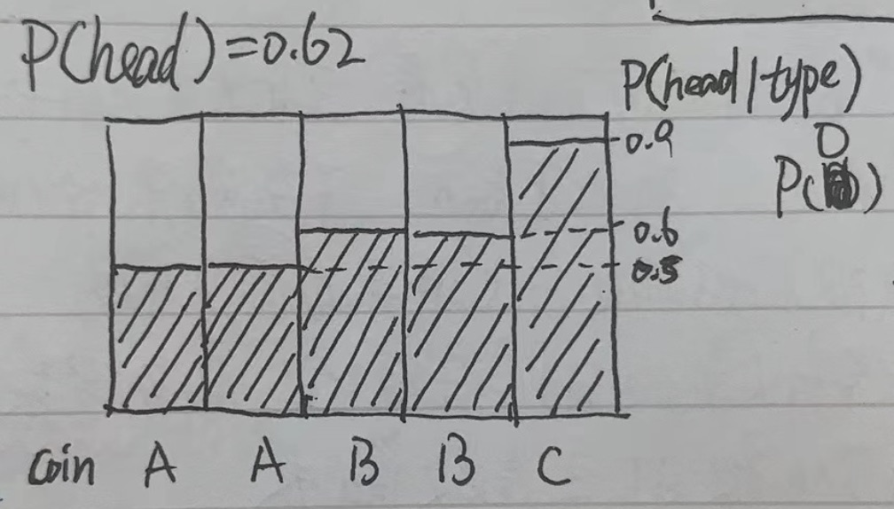

$P(D) = P(head\ of\ observe)$

$= area\ of\ the\ shadow\ of\ the\ probability\ space$

$= \frac{0.5\times 2 + 0.6\times 2 + 0.9}{5}$

`= 0.62`

`Step4: now calculate the shrinked probability of observed a Head given certain coin type.`

$P(H|D)=P(H)\frac{P(D|H)}{P(D)}$

[output not shown]

# Question 2. (25 points - Written)

Consider the following dataset of four rows and three features (Malicious, Viagara, Meet) with class labels (ham and spam). Suppose we see a message having these features M5 = (Malicious = ‘yes′ ,Viagara = ‘no′ ,Meet = ‘yes′ ), What is the probability that it is a spam or ham? Using Naive Bayes algorithm.

| S.No | Malicious | Viagara | Meet | class |
| --- | --- | --- | --- | --- |
| M1 | yes | yes | yes | spam |
| M2 | no | no | yes | ham |
| M3 | yes | no | yes | spam |
| M4 | no | yes | no | ham |
| M5 | yes | no | yes | ?% |

`first, calculate the prior knowledge of labels spam & ham`

$given\ P(class=spam)=0.5, P(class=ham)=0.5 $

$and\ P(Malicious=yes) = 0.5, P(Viagara=yes) = 0.5, P(Meet=yes) = 0.75$

$P(spam|X=M5)$

$ = P(spam|yes,no,yes)$

$=\frac{P(spam)P(yes,no,yes|spam)}{P(yes,no,yes)}$

$=\frac{P(spam)\times P(Malicious=yes|spam)\times P(Viagara=no|spam)\times P(Meet=yes|spam) + 1}{P(Malicious=yes)\times P(Viagara=no)\times P(Meet=yes) + 2}$

$P(ham|X=M5)$

$ = P(ham|yes,no,yes)$

$=\frac{P(ham)P(yes,no,yes|ham)}{P(yes,no,yes)}$

$=\frac{P(ham)\times P(Malicious=yes|ham)\times P(Viagara=no|ham)\times P(Meet=yes|ham) + 1}{P(Malicious=yes)\times P(Viagara=no)\times P(Meet=yes) + 2}$

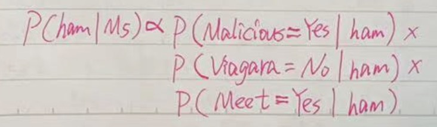

$ $ `since the equations have the same part of factor:` $\frac{1}{P(Malicious=yes)\times P(Viagara=no)\times P(Meet=yes)+2}$ $ $

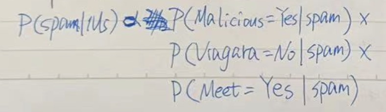

$\therefore P(spam|X=M5)\varpropto P(spam)\times𝑃(𝑀𝑎𝑙𝑖𝑐𝑖𝑜𝑢𝑠=𝑦𝑒𝑠|𝑠𝑝𝑎𝑚)×𝑃(𝑉𝑖𝑎𝑔𝑎𝑟𝑎=𝑛𝑜|𝑠𝑝𝑎𝑚)×𝑃(𝑀𝑒𝑒𝑡=𝑦𝑒𝑠|𝑠𝑝𝑎𝑚)+1$

$\varpropto{2/4\times2/2\times1/2\times2/2+1}$

$=1.25$

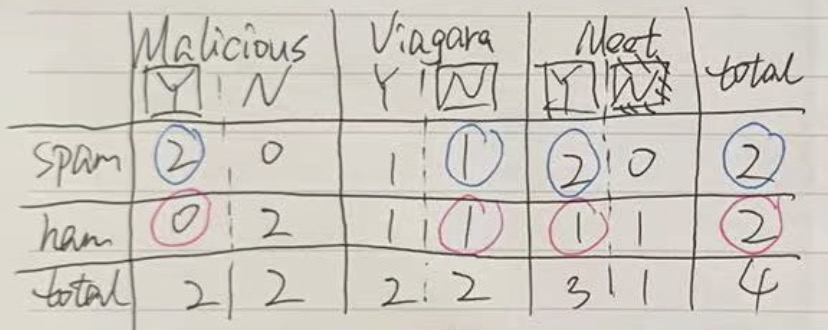

$\therefore P(ham|X=M5)\varpropto P(spam)\times𝑃(𝑀𝑎𝑙𝑖𝑐𝑖𝑜𝑢𝑠=𝑦𝑒𝑠|ham)×𝑃(𝑉𝑖𝑎𝑔𝑎𝑟𝑎=𝑛𝑜|ham)×𝑃(𝑀𝑒𝑒𝑡=𝑦𝑒𝑠|h𝑎𝑚)+1$

$\varpropto{2/4\times0/2\times1/2\times1/2+1}$

$=1$

$\therefore$ M5 has a $\frac{1.25}{1.25+1}=55.6\%$ probability to be spam, and has a 44.4% probability to be ham.

# Question 3.(30 points - Written)

Use the below gradient descent algorithm to find the x value that minimizes the function $f(x) = 6x^{2}_{1} − 3x_1x_2 + 2x^2_2$ .

Choose the starting point as $(x^{(0)}_1 , x^{(0)}_2 ) = (2,3)$ and use the $η_k$ as 0.1 ans ε as 0.0001

Consider the following gradient descent algorithm (which is a variant of the directional search algorithm) that aims to find the x value that minimizes the function f(x).

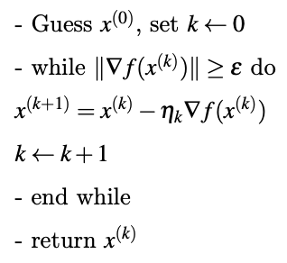

Perform only 3 iterations of this algorithm and report the values of $(x_1, x_2)$ after performing gradient descent each time

$\because f(x) = 6x^{2}_{1} − 3x_1x_2 + 2x^2_2$

$\therefore\frac{\partial f(x)}{\partial x_1}=12x_1-3x_2+2x_2^2\ \ ,\ \ \frac{\partial f(x)}{\partial x_2}=6x_1^2-3x_1+4x_2$

$\therefore\nabla f(x^{(k)})=[\frac{\partial f(x)}{\partial x_1}, \frac{\partial f(x)}{\partial x_2}]$

$\because\nabla f(x^{(k)})>\epsilon=0.0001\ and\ \eta_k=0.1$

$then,\ x^{k+1}=x^{k}-0.1\times[\frac{\partial f(x)}{\partial x_1}, \frac{\partial f(x)}{\partial x_2}]$

**`Perform 3 iterations of gradient descent`**

[output not shown]

```python
# for self-check
import matplotlib.pyplot as plt
from mpl_toolkits.mplot3d import Axes3D
import numpy as np
import math
def f(x1, x2):
    return 6*x1**2 - 3*x1*x2 + 2*x2**2
def fx1(x1, x2):
    return 12*x1-3*x2+2*x2**2
def fx2(x1, x2):
    return 6*x1**2-3*x1+4*x2
def mold(px1, px2):
    return math.sqrt((px1 ** 2 + px2 ** 2))
x1,x2=-0.8, -0.9
print("%d | [%d,%d]" % (f(x1,x2), fx1(x1,x2), fx2(x1,x2)))
T1=np.array([2,-1.3,0.2,-0.8,-0.3])
T2=np.array([3,0,-1.4,-0.9,-1.1])
T3=f(T1,T2)
```

```
3 | [-5,2]
```

**`Report`**

| $$k$$ | $$x_1^{(k)}$$ | $$x_2^{(k)}$$ |
| --- | --- | --- |
| 0 | 2 | 3 |
| 1 | -1.3 | 0 |
| 2 | 0.2 | -1.4 |
| 3 | -0.8 | -0.9 |

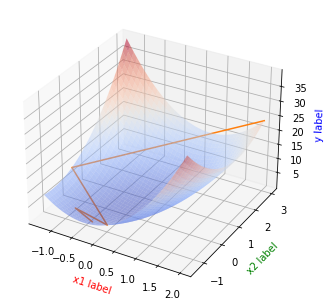

```python
# self-check visualization
fig1 = plt.figure()
ax = Axes3D(fig1)
X1, X2 = np.mgrid[-1.3:2:40j, -1.4:3:40j]
Y = f(X1, X2)
ax.plot_surface(X1, X2, Y, rstride=1, cstride=1, cmap=plt.cm.coolwarm, alpha=0.5)
ax.plot(T1, T2, T3)
ax.set_xlabel('x1 label', color='r')
ax.set_ylabel('x2 label', color='g')
ax.set_zlabel('y label', color='b')
plt.show()
```

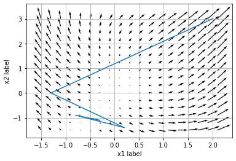

```python
# self-check visualization
import numpy as np
import matplotlib.pyplot as plt
def numerical_gradient(f,P):
    grad = np.zeros_like(P)
    for i in range(P[0].size):
        grad[0][i] = fx1(P[0][i], P[1][i])
        grad[1][i] = fx2(P[0][i], P[1][i])
    return grad
lx1,rx1,r1=-1.5,2,0.2
lx2,rx2,r2=-1.5,3,0.3
x = np.arange(lx1, rx1+r1, r1)
y = np.arange(lx2, rx2+r2, r2)
X, Y = np.meshgrid(x, y)
X = X.flatten()
Y = Y.flatten()
grad = numerical_gradient(f, np.array([X, Y]))
plt.quiver(X, Y, grad[0], grad[1])
T1=np.array([2,-1.3,0.2,-0.8,-0.3])
T2=np.array([3,0,-1.4,-0.9,-1.1])
T3=f(T1,T2)
plt.plot(T1,T2,T3)
plt.xlim([lx1*1.2, rx1*1.2])
plt.ylim([lx2*1.2, rx2*1.2])
plt.xlabel('x1 label')
plt.ylabel('x2 label')
plt.grid()
plt.show()
```

## Extra work for a better learning rate visualization

```
break when gradient vanished: 0.000090<0.000100 after 38 times.
break when gradient vanished: 0.000091<0.000100 after 66 times.
break when iterate 10001 times with gradient 9.033484.
```

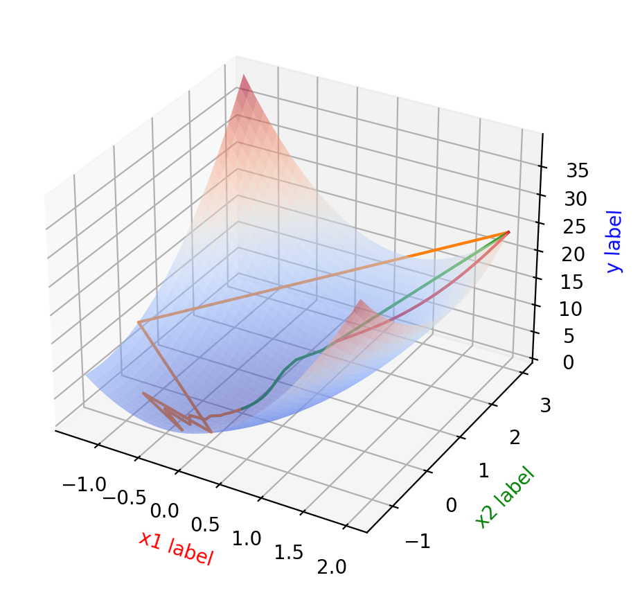

```python
# visualization for a better learning rate
def gradient_decent(x1, x2, alpha=0.05, epsilon=0.0001, max_iter=10000):
    x1, x2 = 2, 3
    px1, px2 = fx1(x1, x2), fx2(x1, x2)
    md = mold(px1, px2)
    T1, T2, T3 = [], [], []
    cnt = 0
    convergence_cnt = 0
    while True:
        if md < epsilon:
            print("break when gradient vanished: %.6f<%.6f after %d times. " % (md, epsilon, cnt))
            break
        if cnt > max_iter:
            print("break when iterate %d times with gradient %.6f. " % (cnt, md))
            break
        if convergence_cnt > 5:
            print("gradient convergence detected. ")
            break
        T1.append(x1)
        T2.append(x2)
        T3.append(f(x1, x2))
        px1 = fx1(x1, x2)
        px2 = fx2(x1, x2)
        tmp = mold(px1, px2)
        if tmp > md:
            convergence_cnt += 1
        md = tmp
        x1 = x1 - alpha * px1
        x2 = x2 - alpha * px2
        cnt += 1
    return T1, T2, T3

# print(T1,"\n",  T2,"\n",  T3)
fig1 = plt.figure(dpi=200)
ax = Axes3D(fig1)
X1, X2 = np.mgrid[-1.3:2:40j, -1.4:3:40j]
Y = f(X1, X2)
ax.plot_surface(X1, X2, Y, rstride=1, cstride=1, cmap=plt.cm.coolwarm, alpha=0.5)
T1,T2,T3=gradient_decent(2,3,alpha=0.1)
ax.plot(T1, T2, T3)
T1,T2,T3=gradient_decent(2,3,alpha=0.05)
ax.plot(T1, T2, T3)
T1,T2,T3=gradient_decent(2,3,alpha=0.00001)
ax.plot(T1, T2, T3)
ax.set_xlabel('x1 label', color='r')
ax.set_ylabel('x2 label', color='g')
ax.set_zlabel('y label', color='b')
plt.show()
```

```
gradient convergence detected.
break when gradient vanished: 0.000090<0.000100 after 38 times.
break when gradient vanished: 0.000097<0.000100 after 7 times.
break when iterate 10001 times with gradient 0.249849.
```

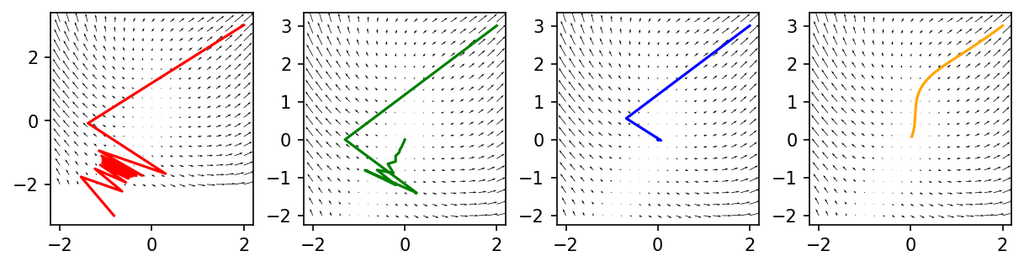

```python
lx1,rx1,r1=-2,2,0.2
lx2,rx2,r2=-2,3,0.3
x = np.arange(lx1, rx1+r1, r1)
y = np.arange(lx2, rx2+r2, r2)
X, Y = np.meshgrid(x, y)
X = X.flatten()
Y = Y.flatten()
grad = numerical_gradient(f, np.array([X, Y]))

fig = plt.figure(figsize=(8, 2), dpi=150, constrained_layout=True)
gs = plt.GridSpec(1, 4, figure=fig, left=0.1, right=0.9, bottom=0.1, top=0.9, wspace=0.05, hspace=0.05)
ax1 = fig.add_subplot(gs[0,0])
ax2 = fig.add_subplot(gs[0,1])
ax3 = fig.add_subplot(gs[0,2])
ax4 = fig.add_subplot(gs[0,3])

def plot_gradient_path(ax, t1,t2, clr):
    ax.quiver(X, Y, grad[0], grad[1])
    ax.plot(T1,T2, c=clr)

T1,T2,T3=gradient_decent(2,3,alpha=0.1027)
plot_gradient_path(ax1, T1,T2, clr='r')
T1,T2,T3=gradient_decent(2,3,alpha=0.1)
plot_gradient_path(ax2, T1,T2, clr='g')
T1,T2,T3=gradient_decent(2,3,alpha=0.081377)
plot_gradient_path(ax3, T1,T2, clr='b')
T1,T2,T3=gradient_decent(2,3,alpha=0.0001)
plot_gradient_path(ax4, T1,T2, clr='orange')
plt.show()
```

# Question 4. (20 points - Written)

Find the eigen values and eigen vectors for the following matrix. $\left[ \begin{matrix} 2&5\\ -1&2\\ \end{matrix} \right] \tag{1}$

$ A\vec x=\lambda \vec x$

$\Rightarrow A\vec x - \lambda I \vec x = 0 $

$\Rightarrow (A - \lambda I) \vec x = 0 $

$\Rightarrow det(A - \lambda I) = \left|\begin{matrix} 2-\lambda&5\\ -1&2-\lambda\\ \end{matrix}\right| = (2-\lambda)^2 - (-1\times5) = 0$

$\Rightarrow \lambda^2 - 4\lambda + 9 = 0$

for $ax^2+bx+c=0,\ \left\{ \begin{aligned} x_1 = m+ni & \\ x_2 = m-ni & \\ \end{aligned} \right. $

$then\ \left\{ \begin{aligned} x_1+x_2 & = -\frac{b}{a} = 4 = 2m\\ x_1\times x_2 & = \frac{c}{a} = 9 = m^2 + n^2\\ \end{aligned} \right. $

$\therefore m= 2,\ n= \sqrt{5}$

$\therefore \lambda_1=2 + \sqrt{5}i,\ \lambda_2=2 - \sqrt{5}i \tag{2}$

```python
# for self-check
import numpy as np
C = np.mat('2,5;-1,2')
c1,c2 = np.linalg.eig(C)
print("eigen values: %s"%(c1))
```

```
eigen values: [2.+2.23606798j 2.-2.23606798j]
```

remember $ A\vec x=\lambda \vec x$

$\Rightarrow \left[\begin{matrix}2&5\\ -1&2\\ \end{matrix}\right]\left[\begin{matrix}x1\\ x2\\ \end{matrix}\right] = \lambda \left[\begin{matrix}1&0\\ 0&1\\ \end{matrix}\right] \left[\begin{matrix}x1\\ x2\\ \end{matrix}\right]$

$\Rightarrow \left[\begin{matrix} 2-\lambda&5\\ -1&2-\lambda\\ \end{matrix}\right]$ $\left[\begin{matrix} x1\\ x2\\ \end{matrix}\right]=0$

$\Rightarrow \left\{\begin{aligned} (2-\lambda)x_1 + 5 x_2 = 0\\ -x_1 + (2-\lambda)x_2 = 0\\ \end{aligned}\right. $

$\Rightarrow \frac{x_1}{x_2} = (2-\lambda)$

for $\lambda_1=2 + \sqrt{5}i$

$\frac{x_1}{x_2} = -\sqrt{5}i$

$\xi_1 = \left[\begin{matrix} x1\\ x2\\ \end{matrix}\right]=\left[\begin{matrix} -\sqrt{5}i\\ 1\\ \end{matrix}\right] \tag{3} $

for $\lambda_2=2 - \sqrt{5}i$

$\frac{x_1}{x_2} = \sqrt{5}i$

$\xi_2 = \left[\begin{matrix} x1\\ x2\\ \end{matrix}\right] = \left[\begin{matrix} \sqrt{5}i\\ 1\\ \end{matrix}\right] \tag{4} $

```python
#self-check
from math import sqrt
a = complex(0,sqrt(5))
A = np.mat('2,5;-1,2')

x1 = np.array([-a,1])
𝜆1 = 2 + a
print("for 𝜆1=%s"%𝜆1)
print("A dot x1: ",np.dot(A,x1))
print("𝜆1 *  x1: " , np.dot(𝜆1,x1))
print()

x2 = np.array([a,1])
𝜆2 = 2 - a
print("for 𝜆2=%s"%𝜆2)
print("A dot x2: ",np.dot(A,x2))
print("𝜆2 *  x2: " , np.dot(𝜆2,x2))
```

```
for 𝜆1=(2+2.23606797749979j)
A dot x1:  [[5.-4.47213595j 2.+2.23606798j]]
𝜆1 *  x1:  [5.-4.47213595j 2.+2.23606798j]

for 𝜆2=(2-2.23606797749979j)
A dot x2:  [[5.+4.47213595j 2.-2.23606798j]]
𝜆2 *  x2:  [5.+4.47213595j 2.-2.23606798j]
```